# Analysis of OMICS data, practical 1

# 20 Running graphical applications from SSH

`firefox &` - open browser

`igv &` - genome viewer

`jupyter notebook` - start notebook

When connected to a remote server via SSH with X11 forwarding enabled (`ssh -X`), you can launch graphical applications that will display on your local computer. This is incredibly useful for bioinformatics tools with graphical interfaces.

**Prerequisites**

- **SSH with X11 forwarding**: Connect using `ssh -X username@server.address.com`
- **X Server on your local machine**:
  - **Windows (MobaXterm)**: Built-in X server (starts automatically)
  - **Mac**: Install [XQuartz](https://www.xquartz.org/)
  - **Linux**: X server already installed

## 20.1 Direct launch (if X11 configured)

### 20.1.1 Example 1: Firefox Web Browser

Launch Firefox from the remote server:

```bash
$ firefox &
```

The `&` at the end runs the program in the background, so you can continue using the terminal.

Firefox will open in a new window on your local screen, but it’s actually running on the remote server!

**Tip**

If Firefox is slow to start, be patient - it’s loading over the network. You can check if it’s running with `ps aux | grep firefox`

### 20.1.2 Example 2: IGV (Integrative Genomics Viewer)

IGV is a popular tool for visualizing genomic data, which you will use during the next practicals:

```bash
$ igv &
```

The IGV graphical interface will appear on your screen, allowing you to:

- Load reference genomes
- View BAM files
- Visualize variant calls
- Explore genomic regions interactively

### 20.1.3 Example 3: Jupyter Notebook

Jupyter Notebook provides an interactive environment for data analysis, which you will also encounter during some of the practicals.

```bash
$ jupyter notebook
```

This will:

1. Start the Jupyter server on the remote machine
2. Attempt to open a browser window
3. Display a URL with a token (e.g., `http://localhost:8888/?token=...`)

**Task 24**

Practice launching graphical applications:

1. Connect to your server with X11 forwarding: `ssh -X -p 2227 username@rstudio.dlab.elte.hu`
2. Verify X11 is working: `echo $DISPLAY`
3. Launch these applications one by one:
   - `firefox`
   - `igv &`
   - `jupyter notebook` (using port forwarding method if preferred)
4. Take a screenshot showing the graphical application window running
5. Submit your screenshot as proof of successful X11 forwarding

**Important:** The screenshot should show:

- The application window (Firefox, IGV, and/or Jupyter)
- Proof it’s running from the remote server (e.g., terminal in background showing the ssh session)

## 20.2 Method 2: Port forwarding (recommended for Jupyter)

For better performance, use SSH port forwarding instead of X11:

1. **Connect with port forwarding:**

```bash
$ ssh -L 8888:localhost:8888 -p 2227 username@rstudio.dlab.elte.hu
```

2. **Start Jupyter on the server:**

```bash
$ jupyter notebook --no-browser
```

3. **Copy the URL** shown in the terminal (looks like `http://localhost:8888/?token=abc123...`)
4. **Paste it into your local browser** (Firefox, Chrome, etc. on your own computer)

**Understanding Port Forwarding**

The `-L 8888:localhost:8888` flag creates a tunnel that forwards port 8888 on your local machine to port 8888 on the remote server. This is more efficient than X11 forwarding for web-based applications.

## 20.3 Checking if X11 Forwarding is Working

Before launching graphical applications, verify X11 is working:

```bash
$ echo $DISPLAY
localhost:11.0
```

If you see output like `localhost:11.0` or similar, X11 forwarding is active!

If it’s empty, reconnect with the `-X` flag:

```bash
$ ssh -X -p 2227 username@rstudio.dlab.elte.hu
```

## 20.4 Common issues and solutions

### 20.4.1 Error: Can’t open display

**Problem:** X11 forwarding is not enabled

**Solution:**

```bash
# Reconnect with X11 forwarding
$ ssh -X -p 2227 username@rstudio.dlab.elte.hu

# Check DISPLAY variable is set
$ echo $DISPLAY
```

### 20.4.2 Application opens but is very slow

**Problem:** Graphical data being sent over network

**Solutions:**

- Use a wired connection instead of WiFi
- For web apps like Jupyter, use port forwarding instead
- Close unnecessary graphical elements
- Use command-line alternatives when possible

### 20.4.3 command not found

**Problem:** Software not installed or not in PATH

**Solution:**

```bash
# Check if the program exists
$ which firefox
$ which igv
```

# 21 Working with Jupyter Notebooks

Jupyter Notebook is an interactive environment that combines code, text, and visualizations in a single document. It’s widely used in data science and bioinformatics for documenting analyses, running code interactively, and sharing results.

## 21.1 What is a Jupyter Notebook?

A Jupyter Notebook consists of:

- **Cells** - individual blocks that contain either code or text
- **Kernel** - the computational engine (e.g., Python, R, Bash)
- **Output** - results displayed directly below code cells
- **Markdown** - formatted text for documentation

Notebooks are saved as `.ipynb` files (IPython Notebook format).

Jupyter Notebooks are a powerful tool for:

- **Documenting your workflow** with Markdown
- **Running code interactively** and seeing immediate results
- **Combining bash commands** with data analysis
- **Creating reproducible analyses** that others can follow
- **Sharing your work** as a single, self-contained file

## 21.2 Launching Jupyter Notebook

As covered in the previous section, either use X11 forwarding or port forwarding to launch Jupyter. See the Running graphical applications from SSH section for more details.

## 21.3 Creating your first notebook

### 21.3.1 Step 1: Navigate to your working directory

In the Jupyter interface, navigate to your home directory and create a folder for this practical:

1. Click **New** → **Folder** (on the right side of the interface)
2. Select the new folder by checking the box next to it
3. Click **Rename** and name it `practical1`
4. Click on the `practical1` folder to enter it

[figure not shown]

Creating a new folder

### 21.3.2 Step 2: Create a new notebook

1. Inside the `practical1` folder, click **New** → **Genomics Environment**
2. A new notebook will open in a new browser tab, named `Untitled.ipynb`.

[figure not shown]

Creating a new notebook

**Notebook interface**

The notebook interface shows:

- **Menu bar** at the top (File, Edit, View, etc.)
- **Toolbar** with common actions (save, add cell, run, etc.)
- **Cells** in the main area
- **Kernel indicator** in the top-right corner

### 21.3.3 Step 3: Save and rename your notebook

1. Click on the notebook name Untitled at the top (next to the Jupyter logo)
2. Type a new name: `tasks1`
3. Click **Rename**

[figure not shown]

Renaming a notebook

The notebook is automatically saved as `tasks1.ipynb` in your `practical1` folder.

**Auto-save**

Jupyter notebooks auto-save periodically, but it’s good practice to manually save frequently using:

- **Ctrl+S** (Windows/Linux) or **Cmd+S** (Mac)
- Or click the save icon (💾) in the toolbar

## 21.4 Selecting a kernel

The **kernel** is the computational engine that executes your code. Different kernels support different programming languages.

### 21.4.1 Checking Current Kernel

Look at the top-right corner of the notebook - it shows the current kernel (e.g., Genomics Environment).

### 21.4.2 Changing the Kernel

If you need to change kernels, because you want to use either a different programming language or a different set of tools:

1. Click **Kernel** in the menu bar
2. Select **Change kernel**
3. Choose from available kernels (Genomics Environment, Python, etc.)

[figure not shown]

Changing the kernel

For this and our following practicals, we’ll use the **Genomics Environment** kernel, which is a custom kernel with a Python base and additional tools for bioinformatics. Bash commands (detailed above) can be run in Jupyter Notebook code cells by using the `!` prefix (see below).

## 21.5 Working with cells

Jupyter notebooks contain two main types of cells:

### 21.5.1 1. Code Cells

Code cells contain executable code. By default, new cells are code cells.

**To run a code cell:**

- Click the cell and press **Shift+Enter** (runs cell and moves to next)
- Or press **Ctrl+Enter** (runs cell and stays in current cell)
- Or click the **Run** button (▶) in the toolbar

**Example - Python code:**

```python
# This is a Python code cell
print("Hello from Jupyter!")
x = 5 + 3
print(f"5 + 3 = {x}")
```

**Output:**

```
Hello from Jupyter!
5 + 3 = 8
```

### 21.5.2 2. Markdown Cells

Markdown cells contain formatted text for documentation, explanations, and notes.

**To create a Markdown cell:**

1. Click on a cell
2. Change it to Markdown using:
   - Dropdown menu in toolbar: **Code** → **Markdown**
   - Or press **Esc** then **M** (keyboard shortcut)

[figure not shown]

Creating a Markdown cell

**To edit a Markdown cell:**

- Double-click the cell (or press **Enter** when selected)
- Type your markdown content
- Press **Shift+Enter** to render it

**Example - Markdown syntax:**

````markdown
# This is a Heading 1
## This is a Heading 2

This is regular text with **bold** and *italic* formatting.

- Bullet point 1
- Bullet point 2

1. Numbered item
2. Another item

`inline code` looks like this
```bash
# Code blocks look like this
ls -la
```
````

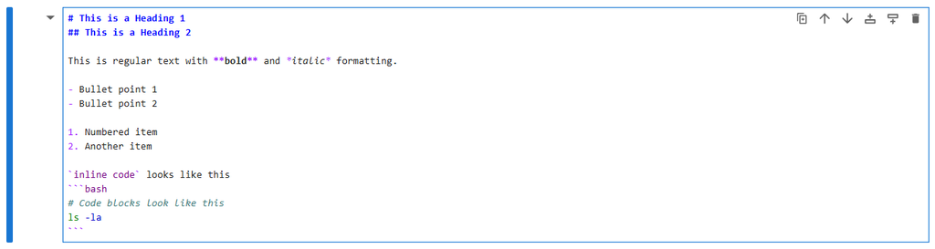

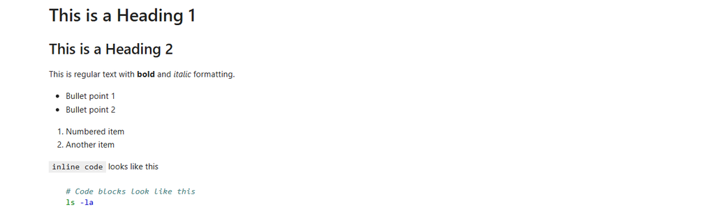

**Markdown Cheat Sheet**

Common Markdown syntax:

- `# Heading` - Creates headings (use #, ##, ###, etc.)
- `**bold**` - Bold text
- `*italic*` - Italic text
- `` `code` `` - Inline code
- `- item` - Bullet points
- `1. item` - Numbered lists
- `` ```language ``` `` - Code blocks
- `[link](https://example.com)` - Links
- `![alt text](image.png)` - Images

## 21.6 Running bash commands in Jupyter

Even when using a Python kernel, you can run bash/terminal commands in Jupyter by prefixing them with `!`

### 21.6.1 The `!` prefix

Any line starting with `!` is executed as a shell command if run from a code cell:

**Example 1: Basic commands**

```python
!pwd
!whoami
!hostname
```

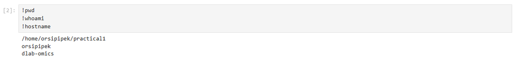

Running bash commands in Jupyter

**Example 2: Listing files**

```python
!ls -lh
```

**Example 3: Creating directories**

```python
!mkdir test_directory
!ls -la
```

**Example 4: File operations**

```python
!touch example.txt
!echo "Hello from Jupyter" > example.txt
!cat example.txt
```

**Example 5: Combining multiple commands**

```python
!echo "File created on:" && date
```

**Important notes about `!` commands**

1. **Each `!` command runs in a new shell** - variables and directory changes don’t persist between or code lines.

```python
   # This WON'T work as expected:
   !cd test_directory
   !pwd  # You're still in the original directory!
```

2. **Capture output as a Python variable:**

```python
   files = !ls -la
   print(files)  # Now 'files' is a list of output lines
```

### 21.6.2 The `%%bash` magic command

The `%%bash` magic command allows you tell a code cell that it should interpret *all of its content* as bash commands and changes to persist between code lines.

**Example:**

```python
%%bash
echo "Hello from Jupyter!"
ls -la
mkdir test_directory
cd test_directory
pwd    # This will show the path to the test_directory
```

[figure not shown]

Running bash commands in Jupyter

## 21.7 Cell operations

### 21.7.1 Adding new cells

- **Click the + button** in the toolbar
- Or press **Esc** then **A** (insert cell Above)
- Or press **Esc** then **B** (insert cell Below)

### 21.7.2 Deleting cells

- Select the cell, press **Esc** then **D, D** (press D twice)
- Or use **Edit** → **Delete Cells**

### 21.7.3 Moving cells

- Use the up/down arrows in the toolbar
- Or **Esc** then **Ctrl+Shift+↑** or **Ctrl+Shift+↓**

### 21.7.4 Copying/pasting cells

- Copy: **Esc** then **C**
- Paste: **Esc** then **V**

## 21.8 Jupyter keyboard shortcuts

Jupyter has two modes:

### 21.8.1 Command mode (press **Esc**)

- **A** - Insert cell above
- **B** - Insert cell below
- **M** - Change to Markdown cell
- **Y** - Change to Code cell
- **D, D** - Delete cell (press D twice)
- **Z** - Undo cell deletion
- **Shift+Up/Down** - Select multiple cells

### 21.8.2 Edit mode (press **Enter**)

- **Ctrl+Enter** - Run cell
- **Shift+Enter** - Run cell and select next
- **Alt+Enter** - Run cell and insert below
- **Ctrl+S** / **Cmd+S** - Save notebook

**Pro tip**

Press **H** in Command mode to see all keyboard shortcuts!

## 21.9 Shutting down Jupyter

When you’re finished:

1. **Save all notebooks** (Ctrl+S / Cmd+S)
2. **Close notebook tabs** in your browser
3. **Shut down the Jupyter server:**
   - In the terminal where Jupyter is running, press **Ctrl+C** twice
   - Or go to the Jupyter home tab and click **Quit**
4. **Exit SSH connection:**

```bash
   exit
```

**Task 25**

Create a Jupyter Notebook that demonstrates all the bash commands you’ve learned. Submit this notebook as your completed practical work.

**Instructions:**

1. **Create a local copy of the notebook template:**
   - Navigate to your `practical1` folder in bash terminal (using `cd` commands)
   - Copy the template notebook from location `/shared/OMICS/practical01/practical1_template.ipynb` to your folder using the `cp` command and rename it to `firstname_lastname_practical1.ipynb` (use your actual name)
   - Open the notebook in Jupyter Notebook and select the **Genomics Environment** kernel
2. **Solve all tasks in the notebook**
- Use Markdown cells for headings and explanations. Even if a task does not require an explanation, feel free to add notes for yourself, so you can remember what you did and why.
- Use Code cells to run bash commands with the `!` prefix or the `%%bash` magic command. **Don’t forget to actually run the commands by pressing *Shift+Enter* or *Ctrl+Enter*!**
- There are a few tasks that require you to use the Terminal to experiment with the commands, however, summarise your observations in a Markdown cell in the notebook.
- For screenshot tasks, create a screenshot, upload it to the `practical1` folder (either using the Jupyter Notebook interface, `scp` from a Terminal or MobaXterm’s File Manager) and insert the image in the Markdown cell.
3. **Save your notebook** (Ctrl+S or Cmd+S)
4. Once you’re finished, send an e-mail to orsolya.pipek@ttk.elte.hu stating that you have completed the tasks. **You do not need to attach the notebook, I will collect it from the server.**

# 22 Summary and Best Practices

## 22.1 Commands you’ve learned

| Command | Purpose | Common Flags |
| --- | --- | --- |
| `whoami` | Display current username | - |
| `hostname` | Display server name | - |
| `pwd` | Print working directory | - |
| `ls` | List files | `-l`, `-a`, `-h`, `-t`, `-r` |
| `tree` | Show directory structure | `-d`, `-L` |
| `cd` | Change directory | - |
| `mkdir` | Create directory | `-p` |
| `touch` | Create empty file | - |
| `mv` | Move or rename files | `-i` |
| `cp` | Copy files | `-r`, `-p`, `-i` |
| `rm` | Remove files/directories | `-r`, `-i`, `-f` |
| `rmdir` | Remove empty directories | - |
| `ln -s` | Create symbolic link | - |
| `unlink` | Remove symbolic link | - |
| `chmod` | Change file permissions | `-R`, `u+w`, `u-w` |
| `df` | Disk free space | `-h` |
| `du` | Disk usage | `-h`, `-s` |
| `wget` | Download files | `-O`, `-P`, `-c` |
| `scp` | Secure copy (transfer files) | `-r`, `-P` |
| `gunzip` | Decompress .gz files | `-k` |
| `tar` | Archive/extract files | `-czvf`, `-xzvf`, `-tzvf` |
| `cat` | Display/concatenate files | - |
| `zcat` | Display compressed files | - |
| `head` | Show first lines | `-n` |
| `tail` | Show last lines | `-n` |
| `less` | View files interactively | - |
| `more` | Simple file viewer | - |
| `wc` | Count lines/words/chars | `-l`, `-w`, `-c` |
| `grep` | Search patterns | `-i`, `-n`, `-c`, `-v` |
| `cut` | Extract columns | `-f`, `-d` |
| `paste` | Merge files side-by-side | `-d` |
| `uniq` | Remove duplicates | `-c`, `-d`, `-u` |
| `sort` | Sort lines | `-n`, `-r`, `-k` |
| `echo` | Print text | `-e`, `-n` |
| `date` | Display date/time | `+%Y%m%d` |
| `man` | Manual pages | - |
| `\\|` (pipe) | Chain commands | - |

## 22.2 Best Practices

1. **Always use tab completion** - Start typing a filename and press Tab
2. **Use descriptive variable names** - `$REFERENCE_GENOME` not `$ref`
3. **Comment your scripts** - Future you will thank you!
4. **Test on small files first** - Before processing huge datasets
5. **Use `less` for large files** - Don’t `cat` gigabyte files!
6. **Keep a lab notebook** - Document your commands and analyses
7. **Use version control** - Git is your friend
8. **Validate your output** - Check results make sense
9. **Document software versions** - Ensures reproducibility
10. **Backup your data** - Especially raw data!
11. **Protect raw data** - Make it read-only with `chmod -R u-w RAW_DATA/`
12. **Use meaningful filenames** - Include dates in ISO format (YYYY-MM-DD)
13. **Check disk space** - Use `df -h` before large operations
14. **Use symbolic links** - Save space when dealing with large files
15. **Keep log files** - Record all commands you run for reproducibility

## 22.3 Common Pitfalls to Avoid

- **Spaces in filenames** - Use `_` or `-` instead
- **Overwriting files** - Be careful with `>` vs `>>`
- **Case sensitivity** - `File.txt` and `file.txt` are different
- **Forgetting to check disk space** - Use `df -h`
- **Not testing commands** - Always test with `-n` or on small data first
- **Hardcoding paths** - Use variables for flexibility

## 22.4 Text Editors Quick Reference

### 22.4.1 nano (easiest for beginners)

```bash
$ nano filename.txt
# Ctrl+O to save, Ctrl+X to exit
```

### 22.4.2 vim (powerful but steep learning curve)

```bash
$ vim filename.txt
# Press 'i' to insert, 'Esc' to exit insert mode
# ':wq' to save and quit, ':q!' to quit without saving
```

### 22.4.3 gedit (graphical, if available)

```bash
$ gedit filename.txt &
```

# 23 Appendix: Quick Reference Card

## 23.1 Essential Commands Cheat Sheet

```bash
# Navigation and information
whoami                      # Show current username
hostname                    # Show server name
pwd                         # Show current directory
ls -lah                     # List all files with details
tree -d -L 2                # Show directory structure (2 levels)
cd directory_name           # Change directory
cd ..                       # Go up one directory
cd ~                        # Go to home directory

# Getting help
man command                 # Read manual page
command --help              # Quick help
command -h                  # Short help (some commands)

# File operations
mkdir dir_name              # Create directory
mkdir -p path/to/dir        # Create nested directories
touch file.txt              # Create empty file
mv old.txt new.txt          # Rename file
mv file.txt folder/         # Move file
cp file.txt copy.txt        # Copy file
cp -r folder1/ folder2/     # Copy directory recursively
rm file.txt                 # Remove file
rm -r folder/               # Remove directory
rm -i file.txt              # Remove with confirmation (safer!)
ln -s target link           # Create symbolic link
unlink link                 # Remove symbolic link
cat file.txt                # Display file
head -n 20 file.txt         # Show first 20 lines
tail -n 20 file.txt         # Show last 20 lines
less file.txt               # View file interactively (q to quit)
wc -l file.txt              # Count lines

# File permissions
chmod u+w file.txt          # Add write permission
chmod u-w file.txt          # Remove write permission
chmod -R u-w folder/        # Recursive permission change
df -h                       # Check disk space
du -sh folder/              # Check directory size

# Download and compress
wget URL                    # Download file
wget -O name.txt URL        # Download with custom name
scp file.txt user@host:path # Copy file to server
scp user@host:file.txt .    # Copy file from server
gunzip file.gz              # Decompress
gunzip -k file.gz           # Decompress, keep original
tar -czvf out.tar.gz folder # Create compressed archive
tar -xzvf file.tar.gz       # Extract archive
tar -tzvf file.tar.gz       # List archive contents

# Text processing
grep "pattern" file.txt     # Search for pattern
grep "^>" file.fasta        # Lines starting with >
grep -v "^#" file.txt       # Exclude comment lines
grep -c "pattern" file.txt  # Count matches
cut -f1,3 file.tsv          # Extract columns 1 and 3
cut -d',' -f2 file.csv      # Extract column 2 (CSV)
paste file1 file2           # Merge files side-by-side
paste -d',' file1 file2     # Merge with comma delimiter

# Sorting and unique
sort file.txt               # Sort lines
sort -n file.txt            # Sort numerically
sort file.txt | uniq        # Remove adjacent duplicates
sort file.txt | uniq -c     # Count unique entries
cat file1 file2 > out.txt   # Combine files

# Variables and loops
VAR="value"                 # Set variable
echo $VAR                   # Use variable
for i in *.txt; do          # Loop over files
  command $i                # Process each file
done

# Pipes and redirection
command1 | command2         # Pipe output
head file | tail -1         # Get specific line
grep ">" file | wc -l       # Count matches
command > file.txt          # Write to file (overwrite)
command >> file.txt         # Append to file

# Useful utilities
echo "text"                 # Print text
echo -e "line1\nline2"      # Print with newlines
echo -e "col1\tcol2"        # Print with tabs
date +%Y-%m-%d              # Current date
date +%Y%m%d_%H%M%S         # Timestamp

# Help and versions
command --help              # Get help
command --version           # Check version
```

*Last updated: 2026-02-12*